# Financial Contributions for the 2020 presidential Election in Oregon

### by Kevin Young

This is an exploration of 2020 US presidential campaign donations in the state of Oregon. For this exploration data analysis, I am researching the 2020 presidential campaign finance data from [Federal Election Commission](http://fec.gov/disclosurep/PDownload.do). The dataset contains financial contribution transactions from 2016 to 2020.

Throughout the analysis, I will attempt to answer the following questions:

1. Which candidate received the most money?
2. Which candidate had the most supporters?
3. Who are those donors? What do they do?
4. Did Bernie Sanders receive more money from men or women?
5. What was the overall trend of donations throughout the campaigns?

```
## [1] 375839     18
```

```
## 'data.frame':    375839 obs. of  18 variables:
##  $ cmte_id          : chr  "C00580100" "C00580100" "C00580100" "C00580100" ...
##  $ cand_id          : chr  "P80001571" "P80001571" "P80001571" "P80001571" ...
##  $ cand_nm          : chr  "Trump, Donald J." "Trump, Donald J." "Trump, Donald J." "Trump, Donald J." ...
##  $ contbr_nm        : chr  "BARNES, GARTH" "SMITH, NATHALIE" "JURVA, FRANZ" "ROSEVEAR, RON" ...
##  $ contbr_city      : chr  "PORTLAND" "PORTLAND" "CORVALLIS" "DALLAS" ...
##  $ contbr_st        : chr  "OR" "OR" "OR" "OR" ...
##  $ contbr_zip       : int  97216 97266 97333 97338 97124 97401 97303 97603 97756 97439 ...
##  $ contbr_employer  : chr  "RETIRED" "RETIRED" "HP" "RETIRED" ...
##  $ contbr_occupation: chr  "RETIRED" "RETIRED" "ENGINEER" "RETIRED" ...
##  $ contb_receipt_amt: num  75 1.5 28 28 25 ...
##  $ contb_receipt_dt : chr  "12-Jun-18" "10-Jul-18" "12-Dec-16" "10-Dec-16" ...
##  $ receipt_desc     : chr  "" "" "" "" ...
##  $ memo_cd          : chr  "" "X" "X" "X" ...
##  $ memo_text        : chr  "" "" "" "" ...
##  $ form_tp          : chr  "SA17A" "SA18" "SA18" "SA18" ...
##  $ file_num         : int  1263561 1301594 1174081 1174081 1248053 1248053 1263561 1263561 1263561 1263561 ...
##  $ tran_id          : chr  "SA17A.1198820" "SA18.1638885" "SA18.293124" "SA18.283273" ...
##  $ election_tp      : chr  "P2020" "P2020" "P2020" "P2020" ...
```

The data set contains 375,839 observations across 18 variables.

# Univariate Plots

From the beginning we can see there are some extreme outliers within this data.

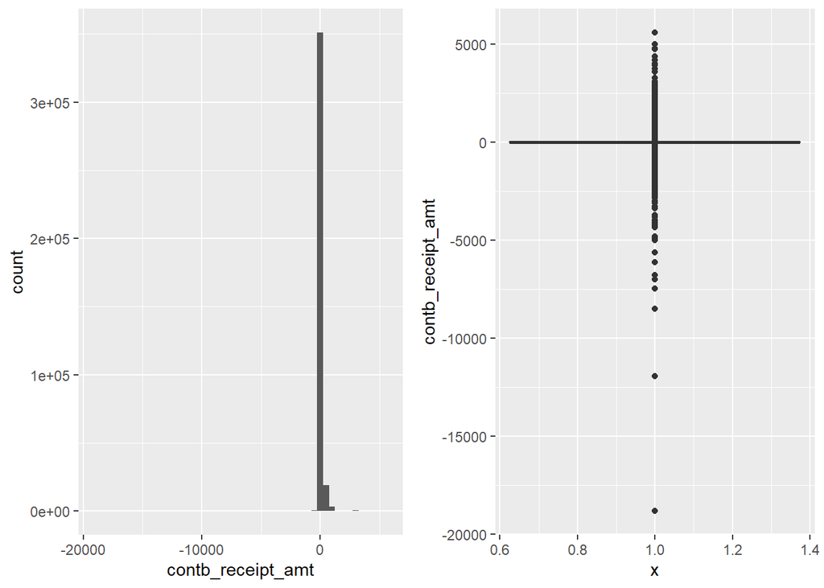

The Contributions are in such close scale I’ll need to cut down on some of the outliers to make it more readable. There are also a lot of negatives in the donations, and those won’t do any good.

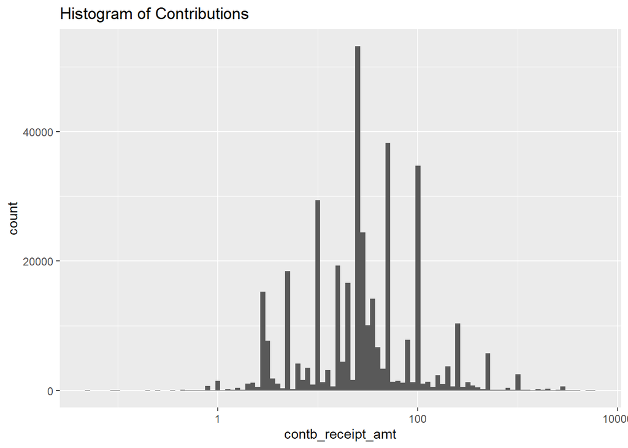

```
##
##    27    10   100    50    25
## 22173 28285 31964 35393 47867
```

```
##    cmte_id            cand_id            cand_nm           contbr_nm
##  Length:375839      Length:375839      Length:375839      Length:375839
##  Class :character   Class :character   Class :character   Class :character
##  Mode  :character   Mode  :character   Mode  :character   Mode  :character
##
##
##
##
##  contbr_city         contbr_st           contbr_zip        contbr_employer
##  Length:375839      Length:375839      Min.   :        0   Length:375839
##  Class :character   Class :character   1st Qu.:    97733   Class :character
##  Mode  :character   Mode  :character   Median :972093271   Mode  :character
##                                        Mean   :707669370
##                                        3rd Qu.:973026235
##                                        Max.   :979185698
##                                        NA's   :11
##  contbr_occupation  contb_receipt_amt   contb_receipt_dt   receipt_desc
##  Length:375839      Min.   :-18811.00   Length:375839      Length:375839
##  Class :character   1st Qu.:    10.00   Class :character   Class :character
##  Mode  :character   Median :    25.00   Mode  :character   Mode  :character
##                     Mean   :    65.86
##                     3rd Qu.:    50.00
##                     Max.   :  5600.00
##
##    memo_cd           memo_text           form_tp             file_num
##  Length:375839      Length:375839      Length:375839      Min.   :1174081
##  Class :character   Class :character   Class :character   1st Qu.:1391415
##  Mode  :character   Mode  :character   Mode  :character   Median :1427451
##                                                           Mean   :1423366
##                                                           3rd Qu.:1458940
##                                                           Max.   :1497668
##
##    tran_id          election_tp
##  Length:375839      Length:375839
##  Class :character   Class :character
##  Mode  :character   Mode  :character
##
##
##
##
```

Scaling the amount to Log10 made it easier to identify the bulk of values, which primarily range at $100 or less.

As we see in the tail the most frequent contribution amount was $25, then $50, then $100. There was a surprising amount of $27 contributions, which is an abnormal non-quartile amount.

The minimum donation is such an abnormally low negative, it is likely an error, and was good to remove. There seems to be an not-insignificant number or negative outliers and high-level donation outliers.

```
## [1] 5366
```

```
## [1] 699
```

The negative donations are likely refunds. The donations over $2800 break personal contribution limits for the 2020 campaign cycle, so those may likely be refunds as well. So the outliers may feed into themselves. Let’s omit them from the data.

Let’s see where these contributions are going. Since this isn’t a national set of data, and the donations are much smaller in total numbers, let’s narrow it to the top 10 candidates by number of contributions.

Then, let’s sort them into their respective political party. Since the bulk of all contributions went to three candidates, I’ll narrow the field to focus on Joe Biden, Donald Trump, and Bernie Sanders.

I’ll also use the gender package to get an estimate of contributors gender to sort into.

```
##
##    Booker, Cory A.     Gabbard, Tulsi  Klobuchar, Amy J.  Harris, Kamala D.
##               1728               1869               3621               3962
##       Yang, Andrew    Buttigieg, Pete Warren, Elizabeth    Sanders, Bernard
##               9408              12670              27268              79570
##   Trump, Donald J. Biden, Joseph R Jr
##              95027             136017
```

Now there are new variables in the data set for me to work with. The party variable and the gender variable.

I can now explore what the contributions look like by gender and by which party the candidates are a part of.

```
## # A tibble: 3 x 5
##   party      sum_party number_of_candidate mean_party      n
##   <chr>          <dbl>               <int>      <dbl>  <int>
## 1 democrat   16954874.                  20    847744. 242283
## 2 others        36802.                   7      5257.    255
## 3 republican  8069909                    7   1152844. 118835
```

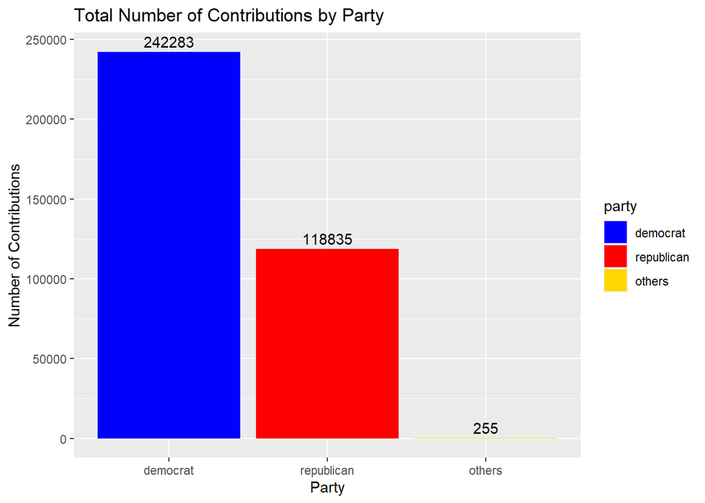

```
## [1] 361373
```

The total number of donations is roughly 361K individual contributions. 242K to the Democrats, 118K to the Republicans, and only 255 individual contributions to all other candidates.

Since Oregon is known to be a very liberal state, this isn’t surprising.

```
##
##         Bennet, Michael F.         Biden, Joseph R Jr
##                        303                     132024
##      Bloomberg, Michael R.            Booker, Cory A.
##                          5                       1719
##             Bullock, Steve            Buttigieg, Pete
##                        303                      12212
##            Castro, JuliÃ¡n           Charles, Mark R.
##                       1062                         47
##           Delaney, John K.             Gabbard, Tulsi
##                          4                       1813
##       Gillibrand, Kirsten      Gravel, Maurice Robert
##                        100                          2
##          Harris, Kamala D.             Hawkins, Howie
##                       3789                         24
##      Hickenlooper, John W.              Inslee, Jay R
##                          8                        537
##              Jorgensen, Jo          Klobuchar, Amy J.
##                         66                       3517
##              Moulton, Seth    Oâ\200\231Rourke, Robert Beto
##                         16                        710
##             Patrick, Deval              Pierce, Brock
##                         11                          1
##           Ryan, Timothy J.           Sanders, Bernard
##                          6                      77047
##      Sestak, Joseph A. Jr.                Steyer, Tom
##                         11                         61
##     Swalwell, Eric Michael           Trump, Donald J.
##                          2                      89345
##                 Walsh, Joe         Warren, Elizabeth
##                         39                      26466
## Weld, William Floyd (Bill)                West, Kanye
##                         36                         72
##      Williamson, Marianne                Yang, Andrew
##                       1116                       8899
```

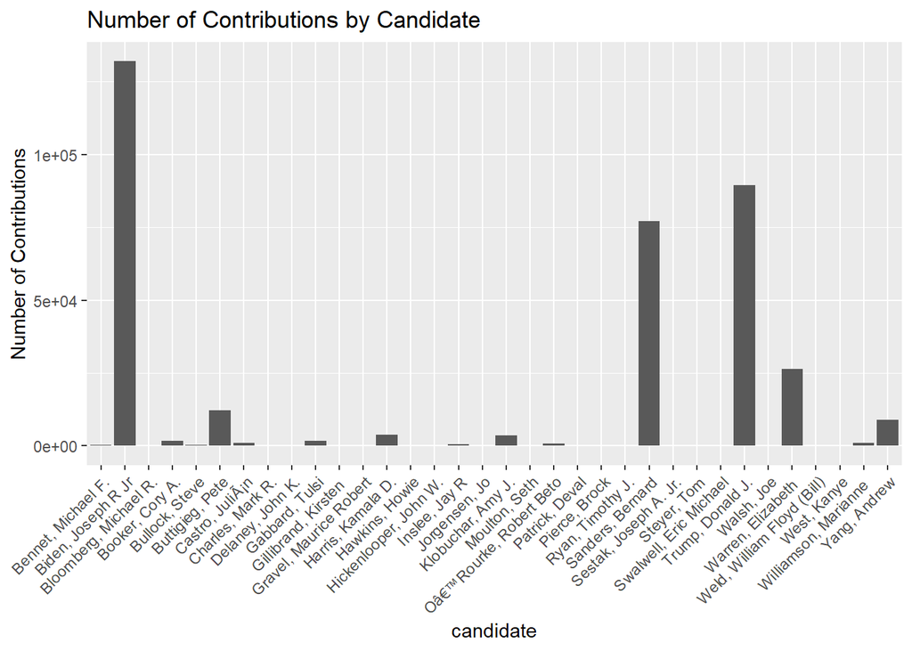

Of the candidates that ran in the 2020 election, Joe Biden had the top amount, followed by Donald Trump. Bernie sanders was a close third for contributions in Oregon.

```
## # A tibble: 2 x 3
##   gender   sum_gen  n_gen
##   <chr>      <dbl>  <int>
## 1 female 11219368. 188039
## 2 male   13842217. 173334
```

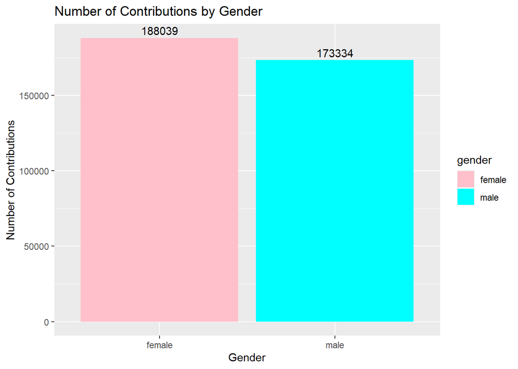

Women had the slight edge over men for donations.

Let’s see who these donors are.

```
## # A tibble: 8 x 4
##   contbr_occupation sum_occu mean_occu      n
##   <ord>                <dbl>     <dbl>  <int>
## 1 NOT EMPLOYED      6926515.      64.0 108234
## 2 RETIRED           4408324.      72.9  60459
## 3 PHYSICIAN          559801.     117.    4770
## 4 TEACHER            246102.      51.9   4741
## 5 <NA>               112603.      25.3   4446
## 6 ATTORNEY           518898.     120.    4321
## 7 ENGINEER           360245.      89.0   4047
## 8 SOFTWARE ENGINEER  265591.      81.3   3265
```

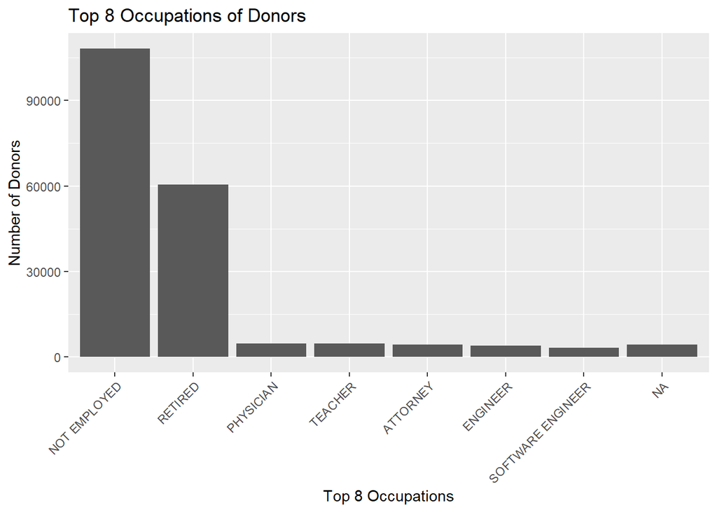

Interesting, there are only 8 available for the top ten occupations, so we’ll order them by those 8 occupations.

Not Employed People take first, followed by Retired people. The rest of the numbers are so extraordinarily low in comparison, it may seem like an outlier. But If we remember the Covid-19 pandemic dominated from March to November of 2020, that could answer why so many contributions were from Unemployed people.

```
##         Min.      1st Qu.       Median         Mean      3rd Qu.         Max.
## "2016-08-07" "2019-12-31" "2020-04-11" "2020-04-07" "2020-09-13" "2020-12-29"
```

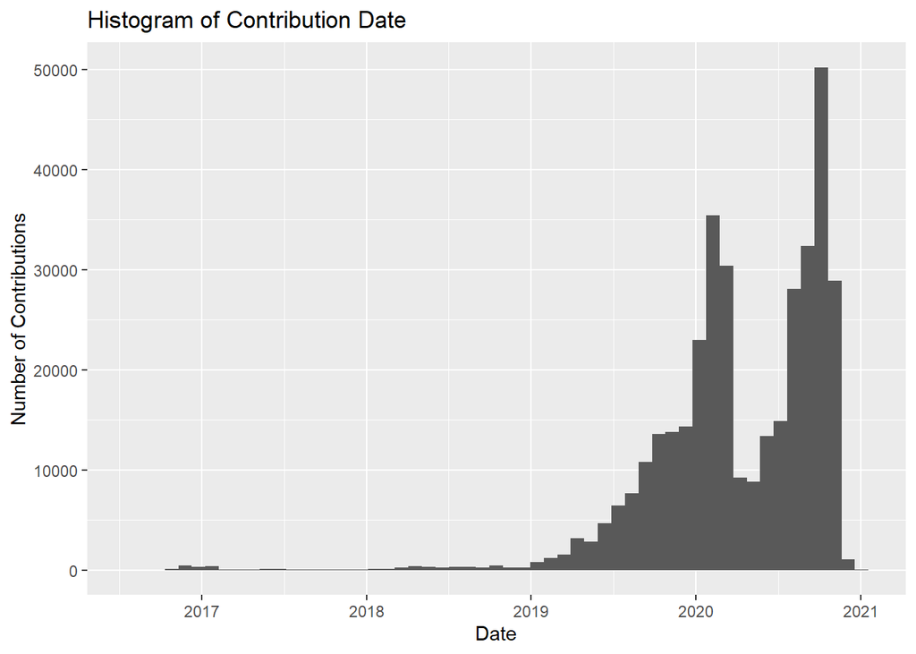

It’s noticeable there was a huge increase in donations the year of the election, which is normal. The highest spikes in contributions are near early 2020, which is when the primaries would be ending, funneling donations to the final two candidates, and then near the end of 2020, right as November hits, which makes sense as it’s right near the election date.

# Univariate Analysis

### What is the structure of your dataset?

Now there are 361,373 observations, and after completing the addition of necessary variables, there are 21 variables to work with.

the most useful variables I’ll be comparing are: * cand_nm: Candidate Name * contbr_nm: Contributor name (for gender analysis) * contbr_occupation: Contributor Occupation * contb_receipt_amt: Contribution Amount * contb_receipt_dt: Contribution date

### What is/are the main feature(s) of interest in your dataset?

the main feature sof interest are the contribution amounts, the difference in total contribution by political party, and the spread of traits across all donors, between gender and occupation and total amount donated.

### What other features in the dataset do you think will help support your

investigation into your feature(s) of interest?

Gender, occupation, and time of the contribution may have a strong effect on the contribution amount and chosen political party.

### Did you create any new variables from existing variables in the dataset?

Gender, and Political Party were created from the existing data. Contributors first name is also used to create the gender prediction.

### Of the features you investigated, were there any unusual distributions?

Did you perform any operations on the data to tidy, adjust, or change the form  
of the data? If so, why did you do this?

Contributions that were either negative or that were above the $2800 limit imposed by federal campaign law were removed from the data.

# Bivariate Plots

```
## # A tibble: 3 x 5
##   party      sum_party number_of_candidate mean_party      n
##   <ord>          <dbl>               <int>      <dbl>  <int>
## 1 democrat   16954874.                  20    847744. 242283
## 2 others        36802.                   7      5257.    255
## 3 republican  8069909                    7   1152844. 118835
```

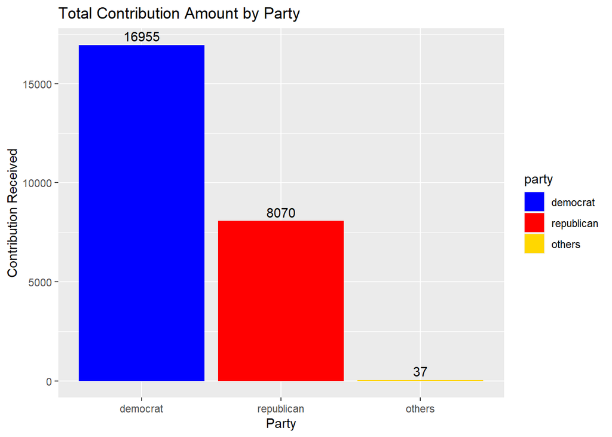

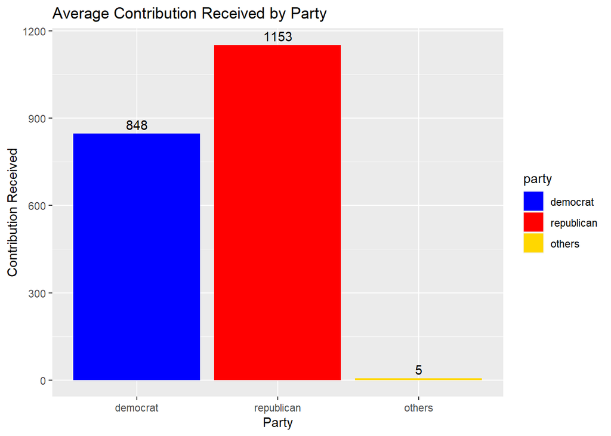

```
## OR$cand_nm
##      Bloomberg, Michael R.           Ryan, Timothy J.
##                     271.72                     285.00
##     Gravel, Maurice Robert           Delaney, John K.
##                     421.00                     500.00
##              Pierce, Brock      Hickenlooper, John W.
##                     500.00                     890.80
##                 Walsh, Joe           Charles, Mark R.
##                    1334.00                    1539.99
##              Moulton, Seth             Patrick, Deval
##                    1580.60                    2900.00
##             Hawkins, Howie      Sestak, Joseph A. Jr.
##                    3467.30                    5225.00
## Weld, William Floyd (Bill)     Swalwell, Eric Michael
##                    5296.32                    5600.00
##                Steyer, Tom       Gillibrand, Kirsten
##                    5819.41                    7354.75
##              Jorgensen, Jo         Bennet, Michael F.
##                   10815.84                   14737.45
##                West, Kanye            Castro, JuliÃ¡n
##                   18860.00                   28446.52
##             Bullock, Steve    Oâ\200\231Rourke, Robert Beto
##                   28811.12                   43212.65
##              Inslee, Jay R      Williamson, Marianne
##                   62094.70                   74624.36
##             Gabbard, Tulsi            Booker, Cory A.
##                  120104.42                  125796.40
##          Harris, Kamala D.          Klobuchar, Amy J.
##                  188555.44                  392111.10
##               Yang, Andrew            Buttigieg, Pete
##                  499046.44                  633243.16
##         Warren, Elizabeth            Sanders, Bernard
##                 1338282.27                 2532893.14
##           Trump, Donald J.         Biden, Joseph R Jr
##                 6572692.13                12334271.62
```

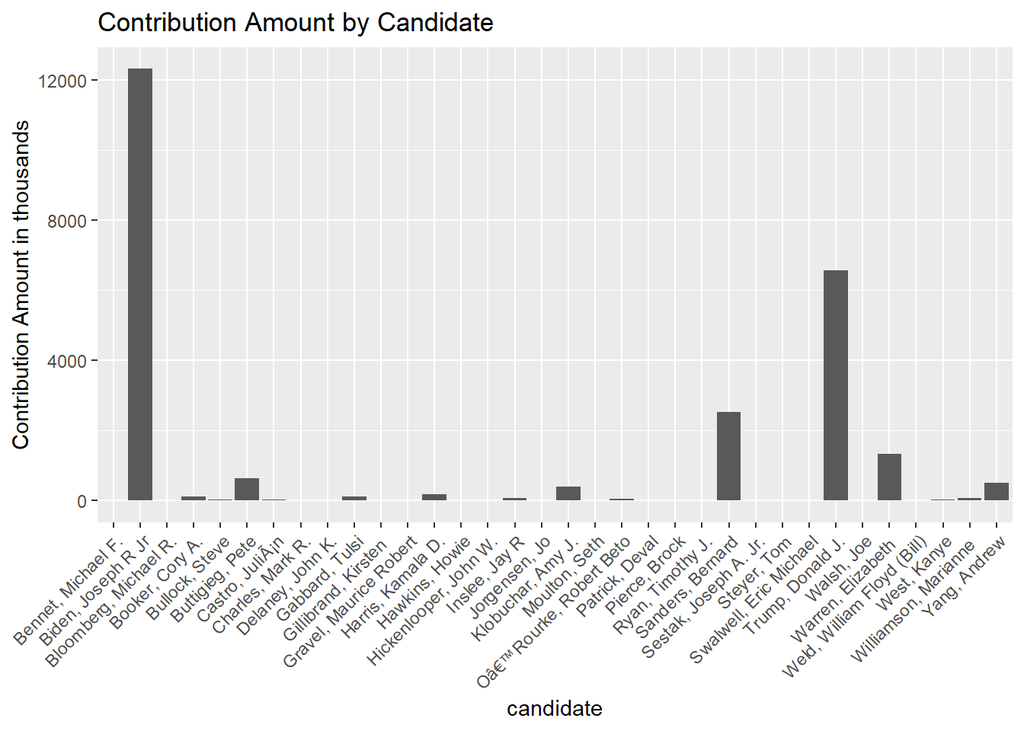

```
## [1] 25061585
```

Over 25 million dollars was in play in contributions in the 2020 Election cycle for Oregon.

Joe Biden took the lion’s share of these donations, followed by Donald Trump, and then Bernie Sanders in third.

Let’s see if we can find more patterns in the contributions.

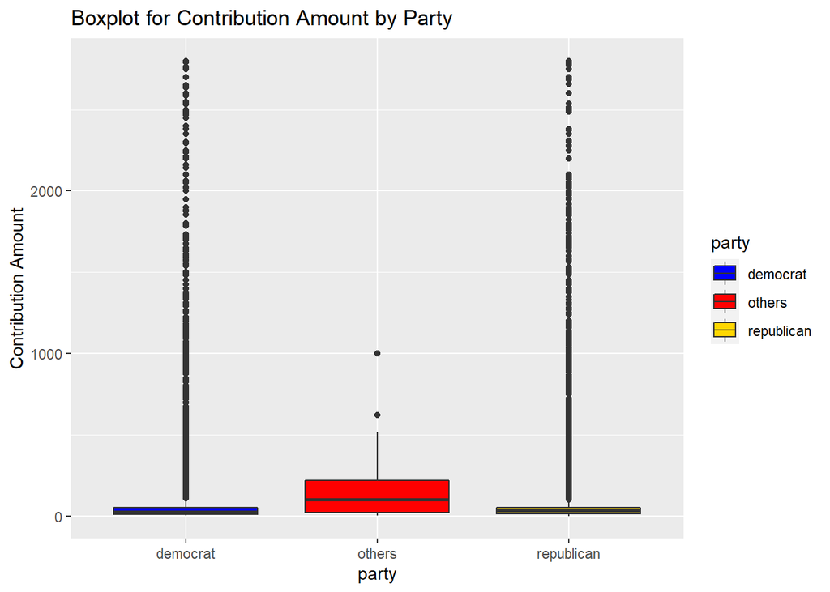

As we see here the most stable median is actual for candidates in “Others”, likely because there were so few contributions total.

Comparably, Democrats and Republicans had a very steady amount of donations across the spectrum, making it hard to narrow down. Let’s try to tidy it a bit by applying the log scale.

```
## OR$party: democrat
##    Min. 1st Qu.  Median    Mean 3rd Qu.    Max.
##    0.91   10.00   25.00   69.98   50.00 2800.00
## ------------------------------------------------------------
## OR$party: republican
##    Min. 1st Qu.  Median    Mean 3rd Qu.    Max.
##    0.05   15.00   31.50   67.91   50.00 2800.00
```

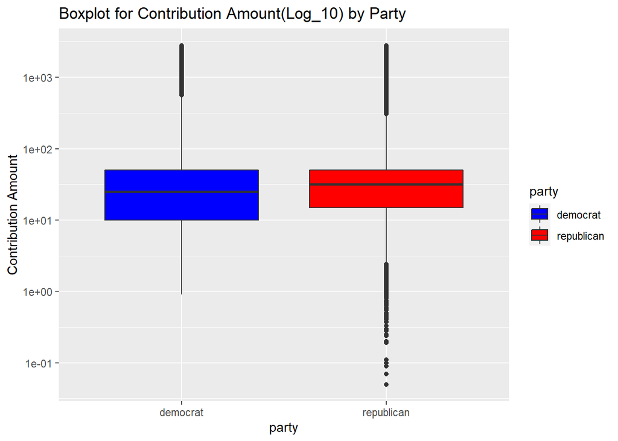

```
## OR$cand_nm: Bennet, Michael F.
##    Min. 1st Qu.  Median    Mean 3rd Qu.    Max.
##    1.00   10.00   25.00   48.64   35.00 2800.00
## ------------------------------------------------------------
## OR$cand_nm: Biden, Joseph R Jr
##    Min. 1st Qu.  Median    Mean 3rd Qu.    Max.
##    1.00   20.00   25.00   93.42  100.00 2800.00
## ------------------------------------------------------------
## OR$cand_nm: Bloomberg, Michael R.
##    Min. 1st Qu.  Median    Mean 3rd Qu.    Max.
##   37.85   48.07   53.25   54.34   53.25   79.30
## ------------------------------------------------------------
## OR$cand_nm: Booker, Cory A.
##    Min. 1st Qu.  Median    Mean 3rd Qu.    Max.
##    1.00   10.00   25.00   73.18   50.00 2800.00
## ------------------------------------------------------------
## OR$cand_nm: Bullock, Steve
##    Min. 1st Qu.  Median    Mean 3rd Qu.    Max.
##    1.00   15.00   35.00   95.09  100.00 2800.00
## ------------------------------------------------------------
## OR$cand_nm: Buttigieg, Pete
##    Min. 1st Qu.  Median    Mean 3rd Qu.    Max.
##    0.91    5.00   20.20   51.85   25.00 2800.00
## ------------------------------------------------------------
## OR$cand_nm: Castro, JuliÃ¡n
##    Min. 1st Qu.  Median    Mean 3rd Qu.    Max.
##    1.00    5.00   15.00   26.79   25.00 1000.00
## ------------------------------------------------------------
## OR$cand_nm: Delaney, John K.
##    Min. 1st Qu.  Median    Mean 3rd Qu.    Max.
##    50.0    87.5   100.0   125.0   137.5   250.0
## ------------------------------------------------------------
## OR$cand_nm: Gabbard, Tulsi
##    Min. 1st Qu.  Median    Mean 3rd Qu.    Max.
##    1.00   19.00   27.00   66.25   67.72 2800.00
## ------------------------------------------------------------
## OR$cand_nm: Gillibrand, Kirsten
##    Min. 1st Qu.  Median    Mean 3rd Qu.    Max.
##    5.00   25.00   25.00   73.55   25.00 1000.00
## ------------------------------------------------------------
```

[output cut: 52 more lines]

```
## OR$cand_nm: Warren, Elizabeth
##    Min. 1st Qu.  Median    Mean 3rd Qu.    Max.
##    0.19   10.00   25.00   50.57   50.00 2800.00
## ------------------------------------------------------------
## OR$cand_nm: Weld, William Floyd (Bill)
##    Min. 1st Qu.  Median    Mean 3rd Qu.    Max.
##    10.0    23.8    25.0   147.1   100.0  1000.0
## ------------------------------------------------------------
## OR$cand_nm: Williamson, Marianne
##    Min. 1st Qu.  Median    Mean 3rd Qu.    Max.
##    1.00   10.00   25.00   66.87   50.00 2700.00
## ------------------------------------------------------------
## OR$cand_nm: Yang, Andrew
##    Min. 1st Qu.  Median    Mean 3rd Qu.    Max.
##    1.00   10.00   25.00   56.08   50.00 2800.00
```

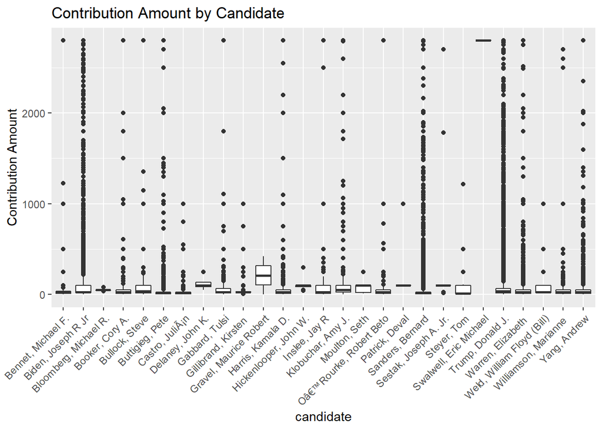

Here is a fascinating bit. The interquartile ranges are so low for nearly all candidates. Yet, the number of plotted points are massive for the three leading candidates. They nearly come out to a straight line from the high number of individual contributions.

Perhaps things will be more precise if we look at the differences within the parties.

```
## # A tibble: 27 x 5
## # Groups:   party [2]
##    party      cand_nm                    sum_can mean_can     n
##    <chr>      <chr>                        <dbl>    <dbl> <int>
##  1 democrat   Bloomberg, Michael R.         272.     54.3     5
##  2 democrat   Gravel, Maurice Robert        421     210.      2
##  3 democrat   Delaney, John K.              500     125       4
##  4 democrat   Hickenlooper, John W.         891.    111.      8
##  5 democrat   Moulton, Seth                1581.     98.8    16
##  6 democrat   Patrick, Deval               2900     264.     11
##  7 democrat   Sestak, Joseph A. Jr.        5225     475      11
##  8 republican Weld, William Floyd (Bill)   5296.    147.     36
##  9 democrat   Swalwell, Eric Michael       5600    2800       2
## 10 democrat   Steyer, Tom                  5819.     95.4    61
## # ... with 17 more rows
```

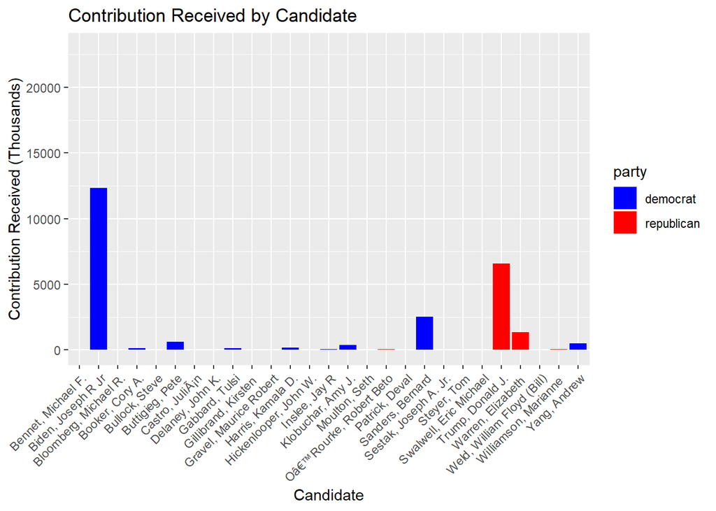

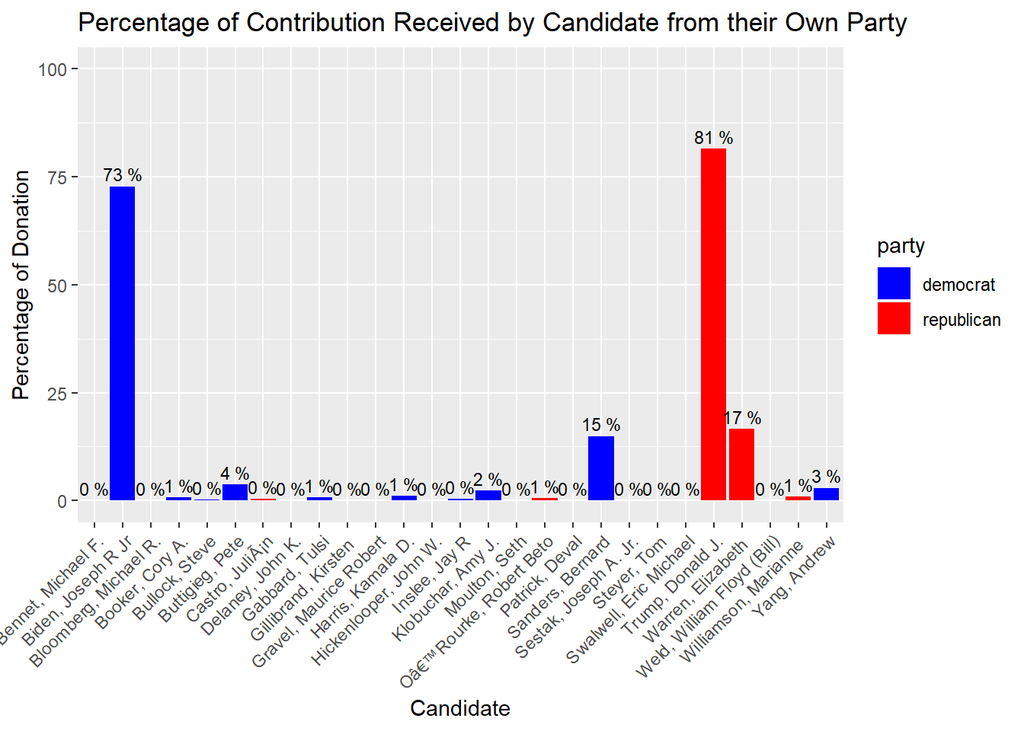

This puts the numbers into more perspective as percentages instead of just dollar amounts. It becomes much more apparent how much of a lead in contributions Joe Biden had over Bernie Sanders, likely because of the many months of time after he was chosen as the Democratic nominee after the primaries. In the Republican corner, Donald Trump took far more of a total from the contributions, as he had the nomination much earlier in the year.

As there were so many candidates in the race, it will be good to narrow the pool down to just the highest-ranked candidates who pulled in the majority of their party’s donations.

```
## [1] "Biden, Joseph R Jr" "Sanders, Bernard"   "Trump, Donald J."
```

We know from above that there was a roughly 8% difference in contributions between women and men. Women contributed about 15,000 more unique donations than men.

Let’s see if that differs by total amount donated as well. After that, I’ll explore where that money was going.

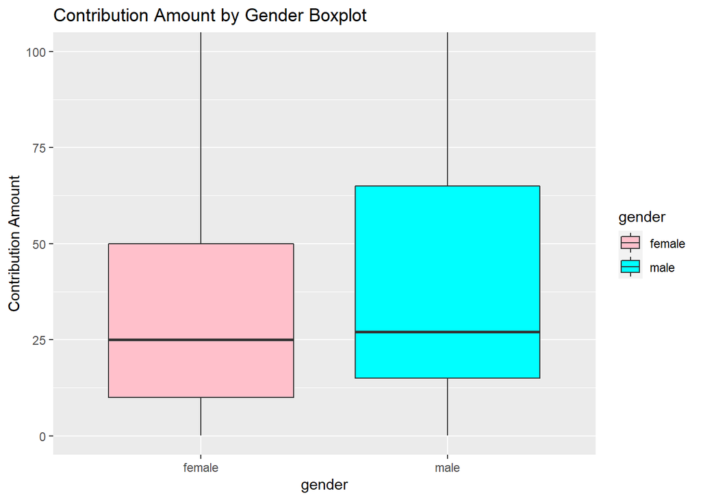

```
## OR$gender: female
##    Min. 1st Qu.  Median    Mean 3rd Qu.    Max.
##    0.05   10.00   25.00   59.66   50.00 2800.00
## ------------------------------------------------------------
## OR$gender: male
##    Min. 1st Qu.  Median    Mean 3rd Qu.    Max.
##    0.05   15.00   27.00   79.77   65.00 2800.00
```

It appears that while women donated more overall contributions, men had a higher mean and median donation. Women donated an average of $59.66, and men an average of $79.77. The median was only $2 more in favor of males.

```
## # A tibble: 2 x 3
##   gender   sum_gen      n
##   <chr>      <dbl>  <int>
## 1 female 11212866. 187961
## 2 male   13811917. 173157
```

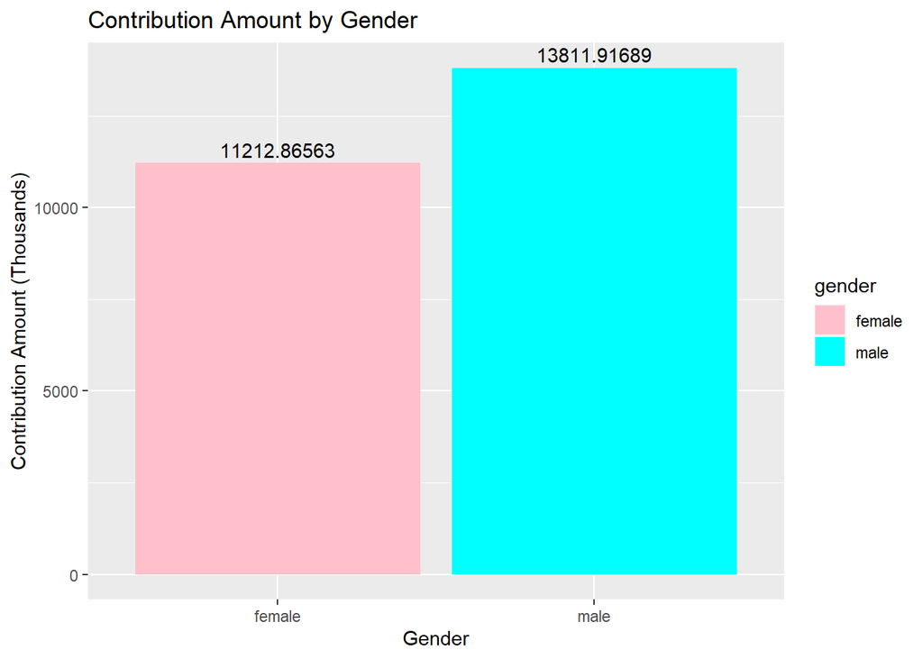

The total contributions puts this into better perspective for the individual amounts by gender. While women did donate more total unique contributions, the total contributions amount donated by men was higher, by nearly 20%. So while less men made donations, the total the men donated was more than the total women donated.

```
## # A tibble: 6 x 3
## # Groups:   cand_nm [3]
##   cand_nm            gender sum_gen_can
##   <chr>              <chr>        <dbl>
## 1 Biden, Joseph R Jr female    5930966.
## 2 Biden, Joseph R Jr male      6403306.
## 3 Sanders, Bernard   female    1026399.
## 4 Sanders, Bernard   male      1506494.
## 5 Trump, Donald J.   female    2537063.
## 6 Trump, Donald J.   male      4035630.
```

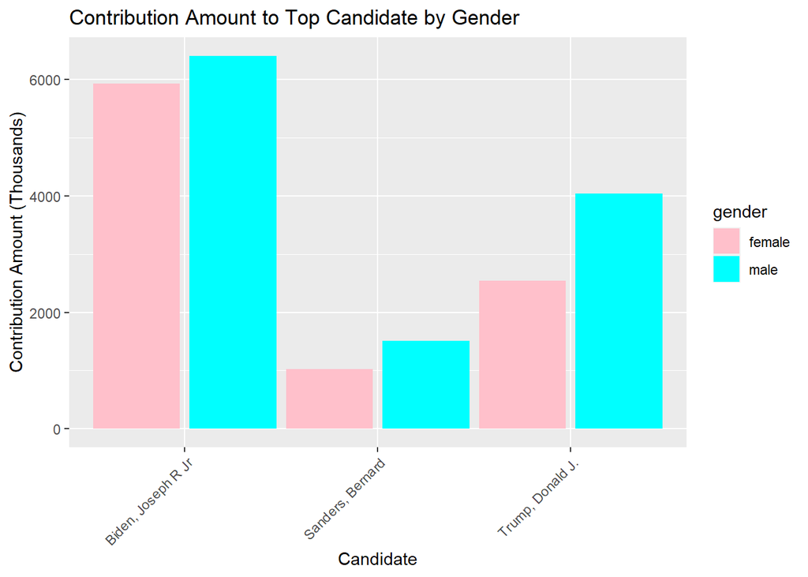

Earlier I plotted what jobs (occupations) the donors had, to see where the contributions were coming from. Let’s look at that again by exploring how much was contributed from each occupation. As we saw, Unemployed people had the most unique contributions. Let’s see the numbers more clearly.

```
## # A tibble: 8 x 4
##   contbr_occupation sum_occu mean_occu      n
##   <ord>                <dbl>     <dbl>  <int>
## 1 NOT EMPLOYED      6926515.      64.0 108234
## 2 RETIRED           4408324.      72.9  60459
## 3 PHYSICIAN          559801.     117.    4770
## 4 TEACHER            246102.      51.9   4741
## 5 <NA>               112603.      25.3   4446
## 6 ATTORNEY           518898.     120.    4321
## 7 ENGINEER           360245.      89.0   4047
## 8 SOFTWARE ENGINEER  265591.      81.3   3265
```

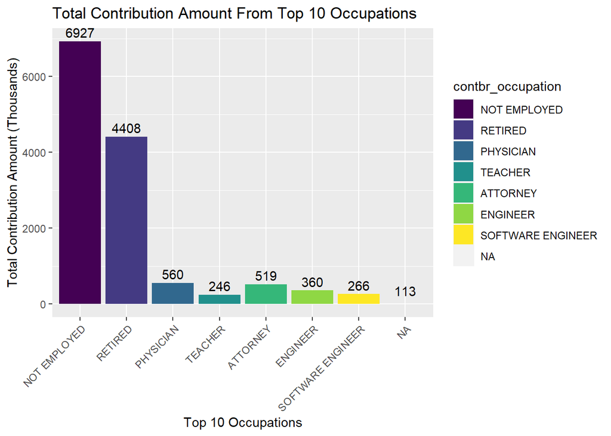

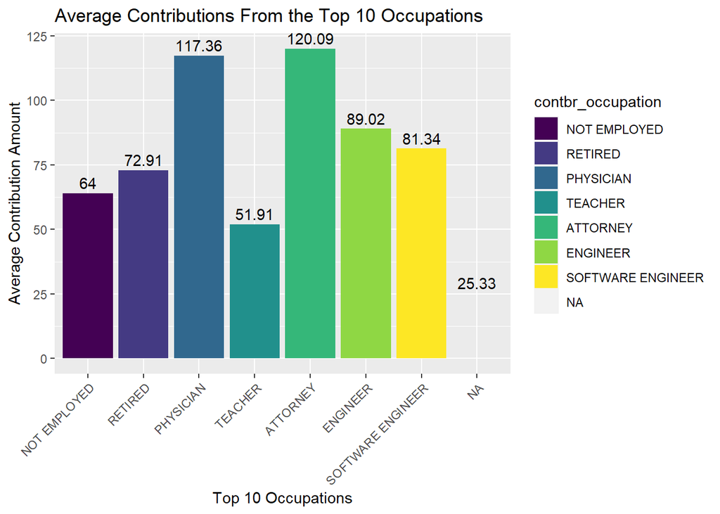

Of the 8 major occupations to measure, while Not Employed had the highest number of contributions, it had the second lowest average contribution amount. Which makes sense as money is tight and during the pandemic many were on unemployment benefits or fixed income. Teacher having the lowest average amount is understandable considering the depressed wages teachers make across the industry nation-wide. The highest average donations were by Attorneys and Physicians, which makes sense as they are highly paid on average.

Software Engineer and Engineer being in the middling averages was surprising, as both of those positions have a high average pay in the Pacific Northwest.

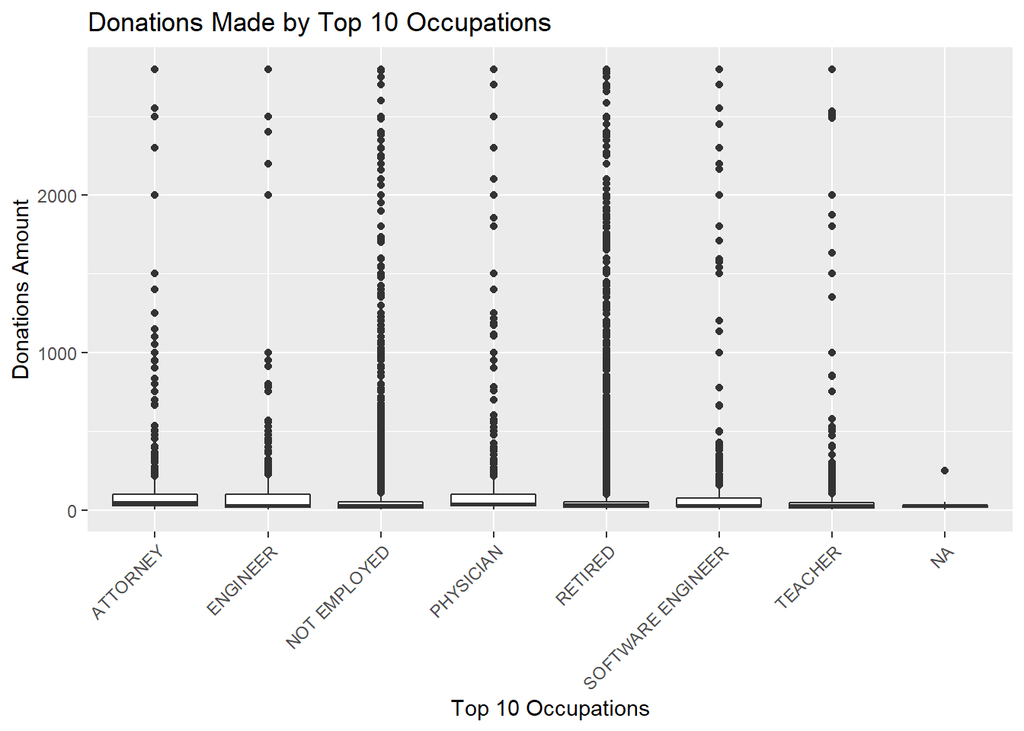

Interesting how there are distinct disparities between then high and low donation amounts for Attorneys and Engineers. Not Employed and Retired have a dense enough spread to cover all levels of donations.

That gap for Engineers is odd though. The data looks a lot different if you cut the limit at 2000, as that’s getting near the limit. Let’s look at the lower level donations, since the mean and median aren’t nearly that high.

```
## top_occu_df$contbr_occupation: ATTORNEY
##    Min. 1st Qu.  Median    Mean 3rd Qu.    Max.
##     1.0    25.0    47.0   120.1   100.0  2800.0
## ------------------------------------------------------------
## top_occu_df$contbr_occupation: ENGINEER
##    Min. 1st Qu.  Median    Mean 3rd Qu.    Max.
##    1.00   17.00   27.00   89.04  100.00 2800.00
## ------------------------------------------------------------
## top_occu_df$contbr_occupation: NOT EMPLOYED
##    Min. 1st Qu.  Median    Mean 3rd Qu.    Max.
##    0.25   10.00   25.00   64.00   50.00 2800.00
## ------------------------------------------------------------
## top_occu_df$contbr_occupation: PHYSICIAN
##    Min. 1st Qu.  Median    Mean 3rd Qu.    Max.
##    0.75   25.00   37.50  117.34  100.00 2800.00
## ------------------------------------------------------------
## top_occu_df$contbr_occupation: RETIRED
##    Min. 1st Qu.  Median    Mean 3rd Qu.    Max.
##    0.05   18.75   33.75   72.90   50.00 2800.00
## ------------------------------------------------------------
## top_occu_df$contbr_occupation: SOFTWARE ENGINEER
##    Min. 1st Qu.  Median    Mean 3rd Qu.    Max.
##    1.00   20.00   27.00   81.36   75.00 2800.00
## ------------------------------------------------------------
## top_occu_df$contbr_occupation: TEACHER
##    Min. 1st Qu.  Median    Mean 3rd Qu.    Max.
##    1.00   10.00   25.00   51.92   48.14 2800.00
```

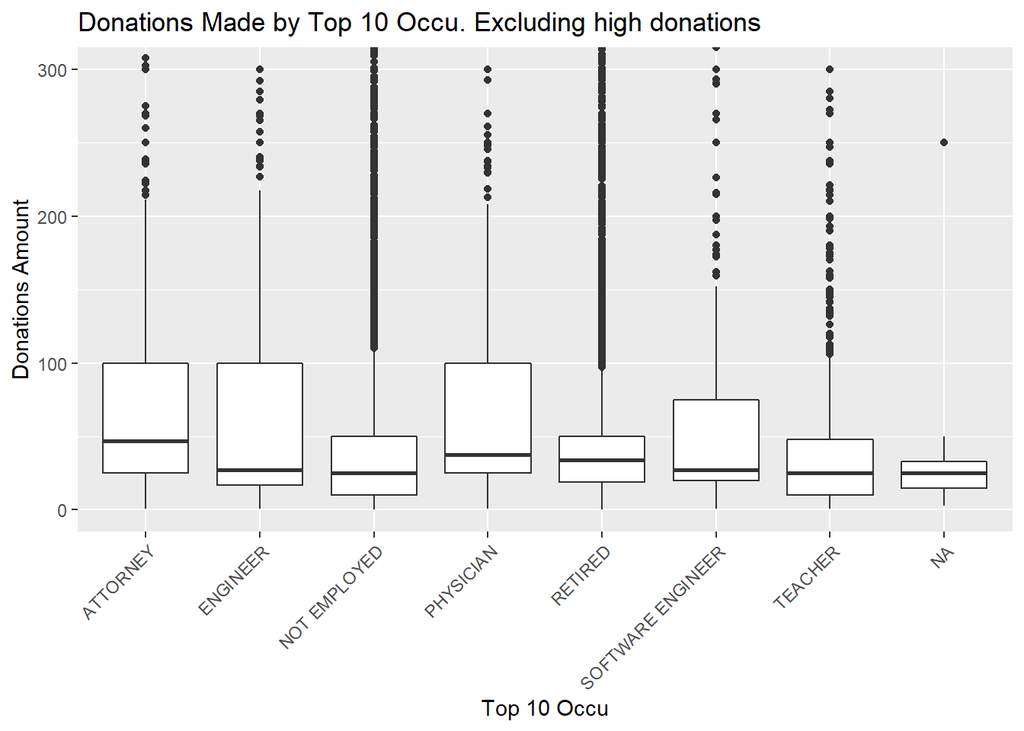

All the other occupations skew lower, starting around closer to $100.

# Bivariate Analysis

The Democrats took well over half of the total contributions in the state of Oregon. Men made a higher contribution amount than women, but overall women made more individual contributions than men. The majority of contributions was made by unemployed and retired people, but the contributions made by people employed in high-wage occupations donated much larger individual sums of money.

### Talk about some of the relationships you observed in this part of the

investigation. How did the feature(s) of interest vary with other features in  
the dataset?

Software Engineers didn’t donate as much to the data as I would have expected, as that is an occupation that is very common in this part of the country.

### Did you observe any interesting relationships between the other features

(not the main feature(s) of interest)?

### What was the strongest relationship you found?

# Multivariate Plots

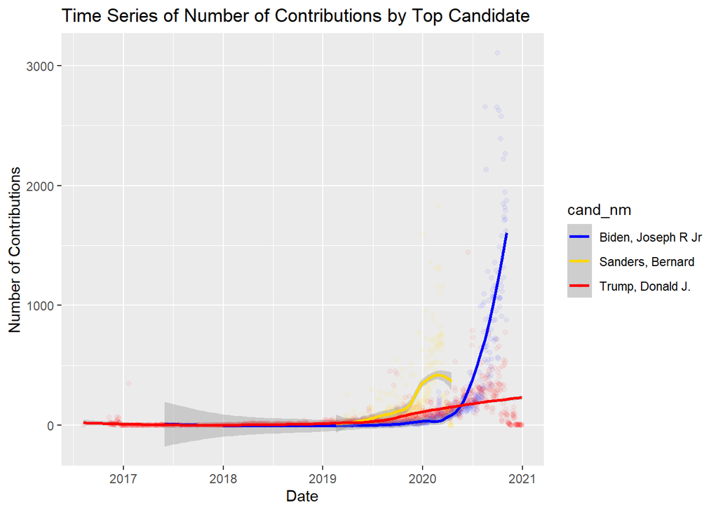

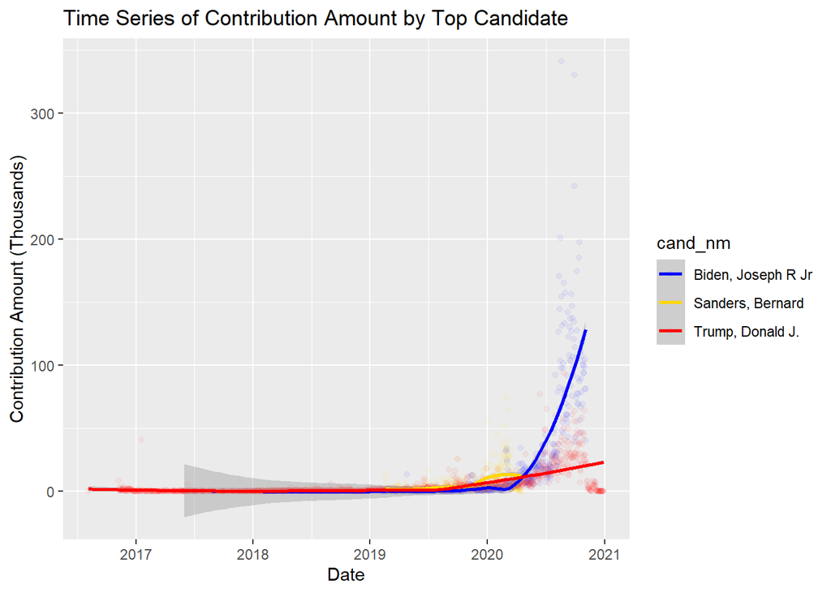

Looking at the timeframe of donations, we see that mid 2020, Bernie Sanders campaign suddenly stopped receiving any donations. Not a downward trend, but just a sudden abrupt end. This can be traced to the Democratic National Convention and Joe Biden clinching the nomination ticket. It looks like it took a bit of time before donations shifted to Joe Biden but they continued to rise in donation up until the election, heavily outpacing Donald Trump. This is in line with the earlier data that showed how much more money went to Democrat candidates overall than Republicans in this dataset.

When we look at the Time series amount by candidate, this becomes even more evident. There is a nexus of all candidates being in the same feild of funding, but once the line for Bernie Sanders stops, the amounts donated to Joe Biden begin to climb exponentially.

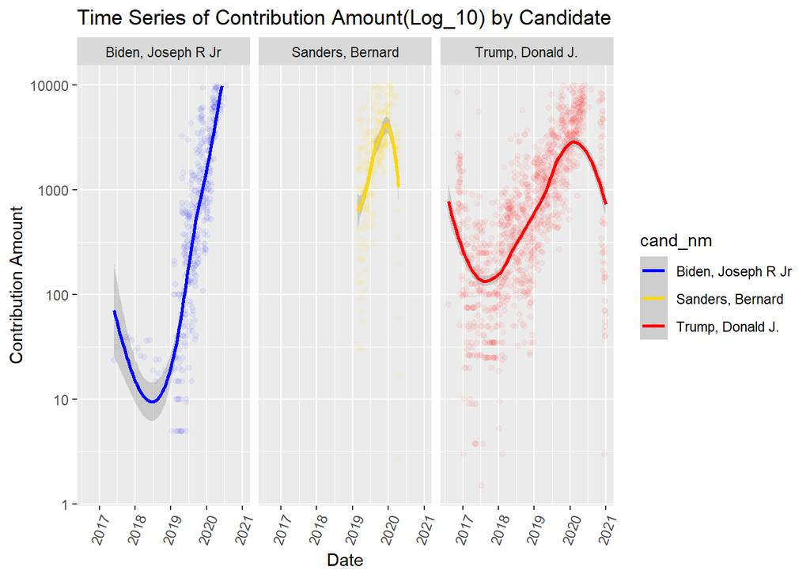

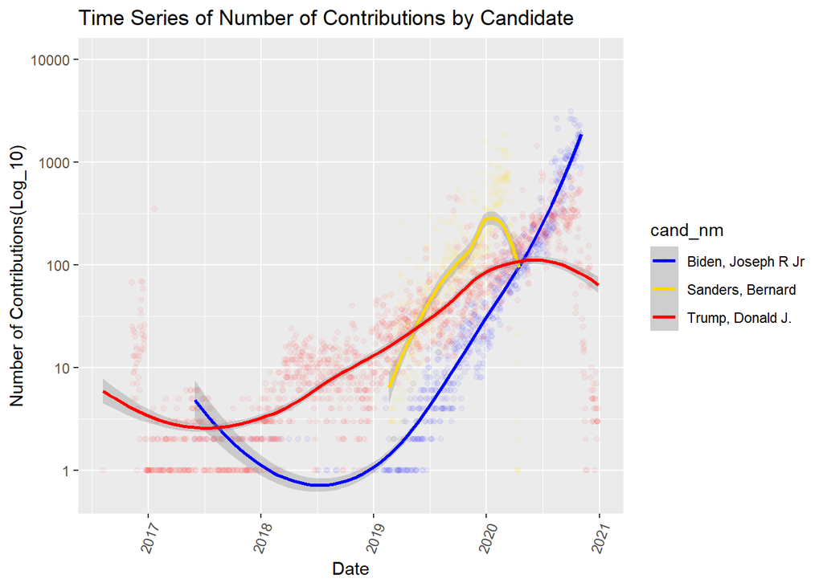

I find this to be rather curious, as we see Joe Bidens donations starting way back in 2017, along with Trumps. Whereas Bernie Sanders begins in 2019, which makes sense, as that’s when most presidential campaigns begin, roughly 19 months before the election. Yet Joe Biden, who said [he would not consider running for President](https://www.businessinsider.com/will-biden-run-for-president-2020-2017-5), finally [announced his campaign in April 2019.](https://www.npr.org/2019/04/25/675382786/joe-biden-officially-announces-2020-presidential-run) The proof is in the data, and it looks like he was indeed accepting contributions to run well before ever announcing his intention.

# Multivariate Analysis

### Were there features that strengthened each other in terms of looking at your feature(s) of interest?

The time series made it clear that as the election neared, it made a substantial impact on Joe Biden’s contribution numbers. Contributions amounts soared as the election neared, once the Nomination was secured.

### Were there any interesting or surprising interactions between features?

# Final Plots and Summary

### Total Contribution by Party

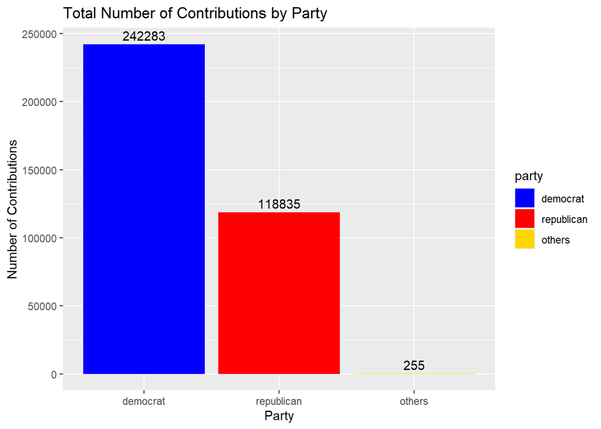

It’s clear that, at least in the state of Oregon, the Democratic party had an unrelenting advantage in gathering contributions to their campaign warchest. They took in 2/3rds of all the political donations in the state.

### Total Contribution by Occupation

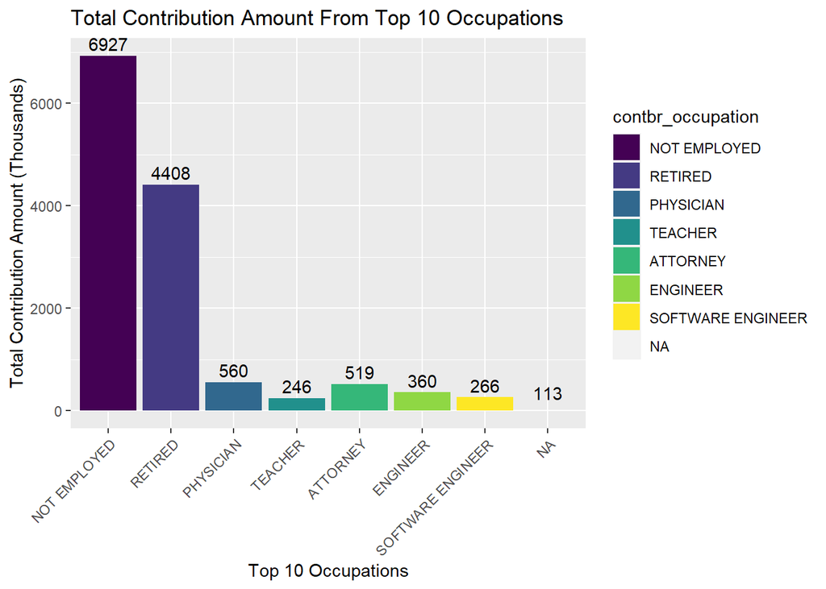

Occupational abnormality can’t be understated in this data set, as so many people who were unemployed donated such a high total number of contributions. This would be a stand-out abnormality in any other election year, but in 2020 the Covid-19 pandemic had such a monumental change on the world that it ground our economy to a halt. It is very telling that this did not result in fewer political donations, but that suddenly unemployed people were still willing to donate over 6 million dollars to their desired candidates.

### Time Series of Contributions

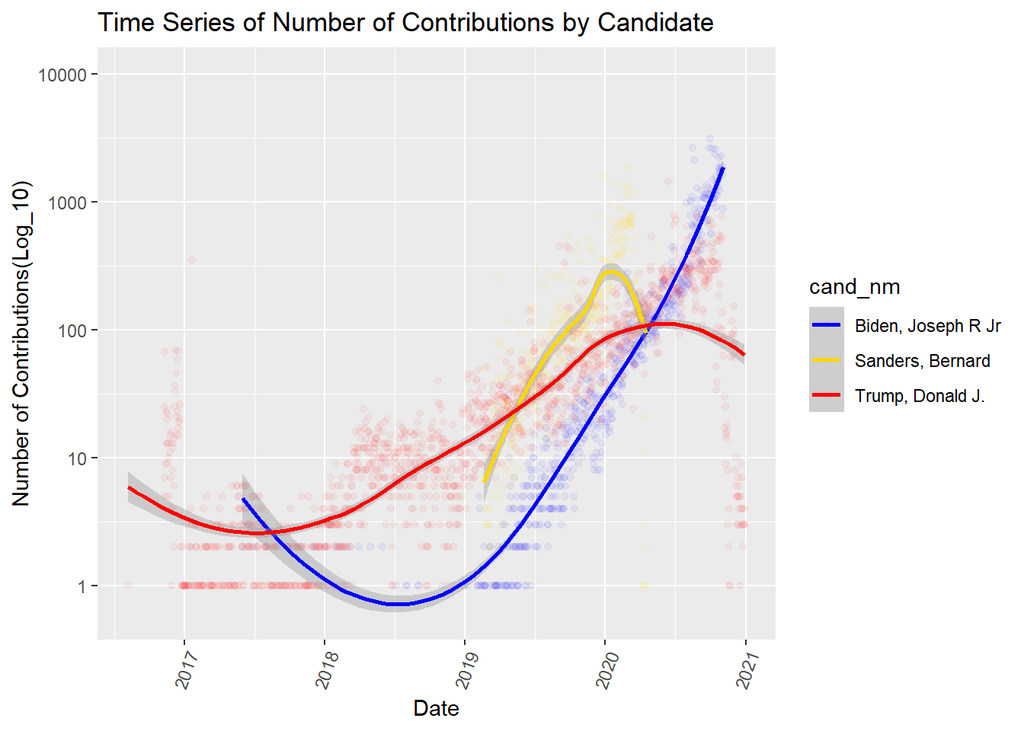

This final plot of the time series of contributions shows a few telling points. * Leading up to the DNC nomination, Bernie Sanders had a fantastic 2019 in fundraising. But throughout early 2020, those high numbers declined as the Primary election drew near. * Joe Biden had a slower start with much lower contribution numbers, but had a linear rise throughout 2020. Once he claimed the nomination, his numbers never stopped going up. * Around the same time, contributions to Donald Trump’s campaign begin to dither, and continued to decline slowly over the course of the year.

# Reflection

### Difficulties

It was a struggle to parse out the data and remove the ancillary candidates, as there were so many prospective candidates in the Democratic party, who ultimately didn’t turn out any major contributions. Once they were removed, it was impressive to see how much money went to just the top candidates in the race.

### Successes

The recommendation to add gender exploration into the data set was very helpful. It was telling to discover the disparity in donation amounts between women and men. It would be even more telling to identify those donations by time series or occupation as well.

It was interesting looking into where the money came from in this state.

### Conclusion

This data set only reflects on the state of Oregon, but it is fascinating to see where the money comes from in these elections. It would be interesting to analyze other states, or the data from the 2016 election.

### Future Work

There were many good points that could be explored in this dataset. One I didn’t go into was using the “contbr_employer” variable to try and find correlation between the employers and the listed occupations of the donors. This could definitely be done with further exploration in this data set. This data is useful for analysis into who is engaged in our area, and who might be worth targeting for better political engagement in future elections. It would be very helpful to map this data by locality as well as time series to see how things changed between the last election and this election, and perhaps use a predictive model to determine how that may change.